# RPTEC_EG

Sem

2025-05-09

```r
library(ggplot2)
library(dplyr)
library(betareg)
```

```r
data_dir <- data_dir <- "C:/Users/semde/Documents/BOO_Scripts/Data/RPTEC_TXG-MAPr"
expression_long   <- readRDS(file.path(data_dir, "expression_long.rds"))
module_definition        <- readRDS(file.path(data_dir, "module_definition.rds"))
eg_score          <- readRDS(file.path(data_dir, "eg_score.rds"))
module_annotation <- readRDS(file.path(data_dir, "module_annotation.rds"))
```

# Introduction

The eigengene scoring method will be evaluated in the Renal Proximal Tubule Epithelial Cell (RPTEC) dataset from the Leiden Academic Center for Drug Research (LACDR). It will be evaluated on the weighted Gene Response Rate (wGRR) metric, which is proposed as an evaluation metric for the topological activation of every unique combination of condition and module. The wGRR presented as the following formula:

$$wGRR = \frac{ \displaystyle \sum_{i}^{n} \left( |\log_2 \mathrm{FC}_i|
> 1.0 \land p_{\mathrm{adj},i} < 0.05 \right) \cdot
\mathrm{cor\_eg}_i }{ n }$$

Here, the binary outcome (0 or 1) for the significance filter is weighted by the cor_eg of each gene. And the total weighted significant genes are divided by the total genes in the module.

# Distribution of Log2FC and adjusted p-value

## Log2FC

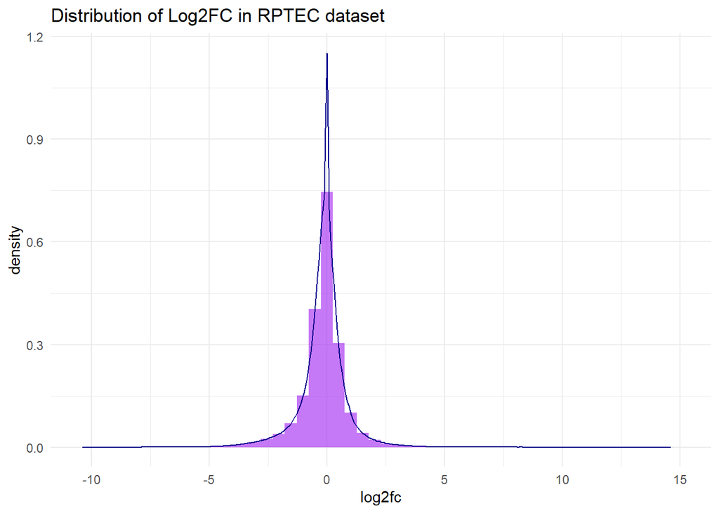

```r
ggplot(expression_long, aes(x = log2fc)) +
  geom_histogram(aes(y = ..density..), bins = 50, fill = "purple", alpha = 0.6) +
  geom_density(color = "darkblue") +
  theme_minimal() + labs(title = "Distribution of Log2FC in RPTEC dataset")
```

```r
sum(abs(expression_long$log2fc) > 1) # total log2fc > 1 ("biologically significant" fold change)
```

```
## [1] 653992
```

## p-adjusted

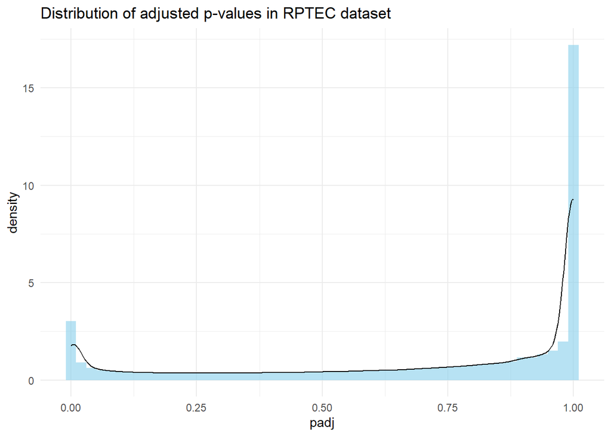

```r
ggplot(expression_long, aes(x = padj)) +
  geom_histogram(aes(y = ..density..), bins = 50, fill = "skyblue", alpha = 0.6) +
  geom_density(color = "black") +
  theme_minimal() +
  labs(title = "Distribution of adjusted p-values in RPTEC dataset")
```

```r
sum(is.na(expression_long$padj)) # Na values in padj
```

```
## [1] 552621
```

Something did not went well with the padj values. Will adjust them myself with same method as pHH according to the TXG-MAPr paper (Benjamini Hochberg)

```r
expression_long$padj <- p.adjust(expression_long$pvalue, method = "BH")
```

```r
sum(is.na(expression_long$padj))
```

```
## [1] 74278
```

```r
sum(is.na(expression_long$padj) & is.na(expression_long$log2fc))
```

```
## [1] 0
```

Still a lot of NA values but there is log2FC data, because these p-values are not significant (source: Giulia).

```r
# Total number of NA genes per condition
expression_long %>%
  group_by(sample_id) %>%
  summarise(n_na = sum(is.na(pvalue))) %>%
  arrange(desc(n_na))
```

```
## # A tibble: 248 × 2
##    sample_id                                              n_na
##    <chr>                                                 <int>
##  1 LU_HRPTECTERT1_SINGLE_HEPATOCYTEGROWTHFACTOR_T1_C1      511
##  2 LU_HRPTECTERT1_SINGLE_HEPATOCYTEGROWTHFACTOR_T1_C2      511
##  3 LU_HRPTECTERT1_SINGLE_HEPATOCYTEGROWTHFACTOR_T1_C3      511
##  4 LU_HRPTECTERT1_SINGLE_HEPATOCYTEGROWTHFACTOR_T2_C1      511
##  5 LU_HRPTECTERT1_SINGLE_HEPATOCYTEGROWTHFACTOR_T2_C2      511
##  6 LU_HRPTECTERT1_SINGLE_HEPATOCYTEGROWTHFACTOR_T2_C3      511
##  7 LU_HRPTECTERT1_SINGLE_BONEMORPHOGENETICPROTEIN4_T1_C1   450
##  8 LU_HRPTECTERT1_SINGLE_BONEMORPHOGENETICPROTEIN4_T1_C2   450
##  9 LU_HRPTECTERT1_SINGLE_BONEMORPHOGENETICPROTEIN4_T1_C3   450
## 10 LU_HRPTECTERT1_SINGLE_BONEMORPHOGENETICPROTEIN4_T2_C1   450
## # ℹ 238 more rows
```

```r
# Total NA values for the modules with eg_score
sum(is.na(eg_score$eg_score))
```

```
## [1] 0
```

ALl the modules still have eg_scores, even if there are missing values for padj and log2fc.

## Significant genes

Total statistically significant genes (padj)

```r
sum(expression_long$padj <  0.05, na.rm = TRUE)
```

```
## [1] 232911
```

## Both Log2FC and padj significant

total biologically significant genes (log2fc > 1 and padj < 0.05)

```r
sum(abs(expression_long$log2fc) > 1 & expression_long$padj < 0.05, na.rm = TRUE)
```

```
## [1] 184290
```

# Gene Response Rate

**This section is not relevant anymore, because now the wGRR is used and not the GRR. However, it is still included in the .Rmd file, if it is decided to use the GRR metric in the future**

The proposed Gene Response Rate reflects the total of significant genes (abs(Log2FC) > 1.0 & padj < 0.05) in a module with size n. This will be plotted against the eigengene score to assess this scoring method.

$$GRR = \frac{ \displaystyle \sum_{i=1}^{n} \left( |\log_2 \mathrm{FC}_i|
> 1.0 \ \land \ p_{\mathrm{adj},i} < 0.05 \right) }{ n }$$

## Merge module_definition with expression_long

```r
expression_long_filtered <- expression_long %>%
  filter(!is.na(padj), !is.na(log2fc)) # Remove NA values for padj and log2FC
```

```r
sum(is.na(expression_long_filtered$padj) & !is.na(expression_long_filtered$log2fc))
```

```
## [1] 0
```

No NA values left

```r
# Add module information, using filtered data
expression_with_module <- expression_long_filtered %>%
  select(entrez_id, sample_id, log2fc, padj) %>%
  inner_join(
    module_definition %>% select(entrez_id, module_number, module_size),
    by = "entrez_id"
  ) %>%
  filter(module_number != 0)  # Remove irrelevant module 0
```

## Calculate significant genes and total per module

Determine what genes are siginificant (log2fc > 1.0 and padj < 0.05)

```r
# Calculate significant genes
expression_with_module <- expression_with_module %>%
  mutate(significant = abs(log2fc) > 1 & padj < 0.05)


# Count significant genes per module
sig_count <- expression_with_module %>%
  group_by(module_number, sample_id) %>%
  summarise(sig_genes = sum(significant), .groups = "drop")
```

## Add the module_size to sig_count and calculate GRR

Divide the total significant genes by the module size

```r
sig_count <- sig_count %>%
  left_join(
    expression_with_module %>%
      distinct(module_number, module_size),
    by = "module_number"
  )
```

```r
sig_count <- sig_count %>%
  mutate(GRR = sig_genes / module_size)
```

## Join GRR with EG score per sample

```r
GRR_vs_eg_score <- sig_count %>%
  inner_join(eg_score, by = c("module_number", "sample_id"))
```

```r
saveRDS(GRR_vs_eg_score, file = "GRR_vs_eg_score_RPTEC.rds")
```

## Density plots of GRR and EG score

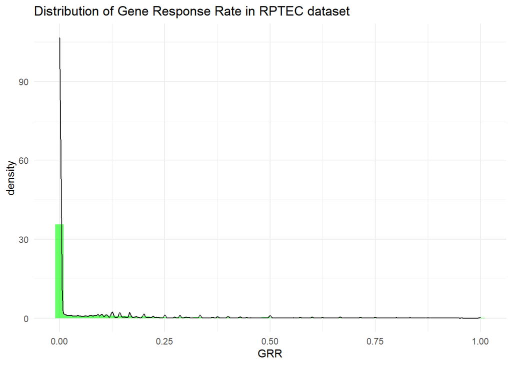

```r
ggplot(GRR_vs_eg_score, aes(x = GRR)) +
  geom_histogram(aes(y = ..density..), bins = 50, fill = "green", alpha = 0.6) +
  geom_density(color = "black") +
  theme_minimal() + labs(title = "Distribution of Gene Response Rate in RPTEC dataset")
```

Like expected, the GRR shows a logaritmic distribution due to the count data nature.

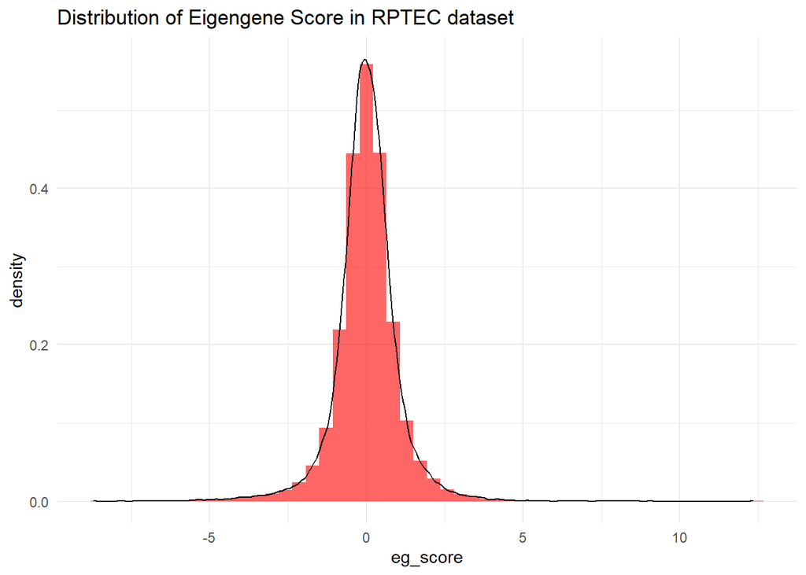

```r
ggplot(GRR_vs_eg_score, aes(x = eg_score)) +
  geom_histogram(aes(y = ..density..), bins = 50, fill = "red", alpha = 0.6) +
  geom_density(color = "black") +
  theme_minimal() + labs(title = "Distribution of Eigengene Score in RPTEC dataset")
```

Eigengene shows a normal distribution, as expected due to the PCA use.

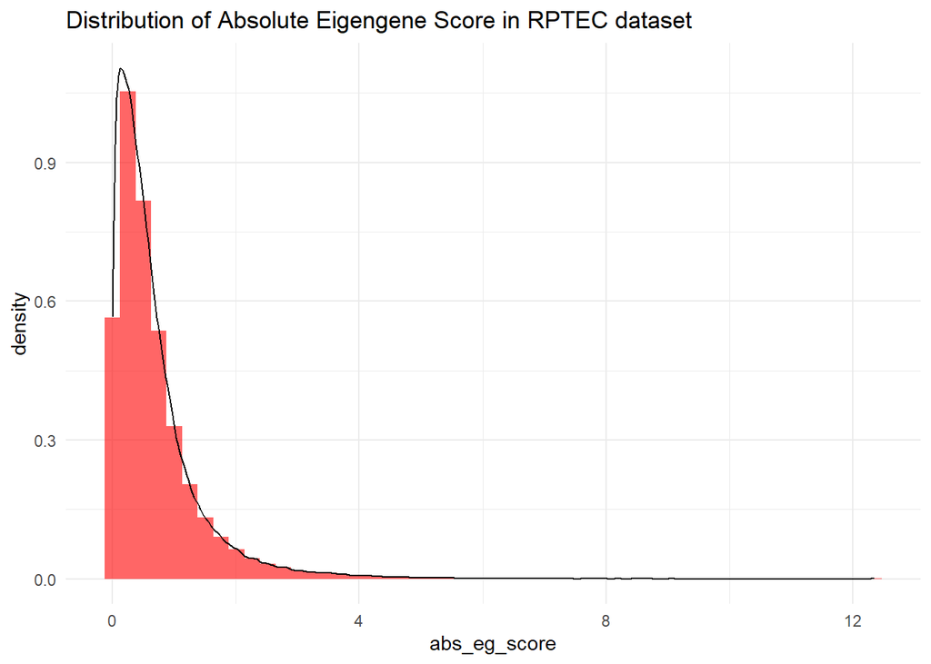

```r
ggplot(GRR_vs_eg_score, aes(x = abs_eg_score)) +
  geom_histogram(aes(y = ..density..), bins = 50, fill = "red", alpha = 0.6) +
  geom_density(color = "black") +
  theme_minimal() + labs(title = "Distribution of Absolute Eigengene Score in RPTEC dataset")
```

## wGRR

It was later decided that the wGRR metric was more representative of topological activation than the GRR metric. This metric was calculated in the hRPTEC_DRW.rmd file and loaded in to visualize it againt the abs_eg_score. The wGRR improves the GRR metric by weighting the genes by their cor_egs, which is used as a measure for their topological importance:

$$wGRR = \frac{ \displaystyle \sum_{i}^{n} \left( |\log_2 \mathrm{FC}_i|
> 1.0 \land p_{\mathrm{adj},i} < 0.05 \right) \cdot
\mathrm{cor\_eg}_i }{ n }$$

```r
GRR_vs_DRW   <- readRDS(file.path(data_dir, "GRR_vs_DRW_cor_eg_RPTEC.rds"))
```

```r
cols_from_DRW <- GRR_vs_DRW %>%
  select(sample_id, module_number, wGRR)

GRR_vs_eg_score <- GRR_vs_eg_score %>%
  left_join(cols_from_DRW, by = c("sample_id", "module_number")) # Joining the wGRR with the eg_scores
```

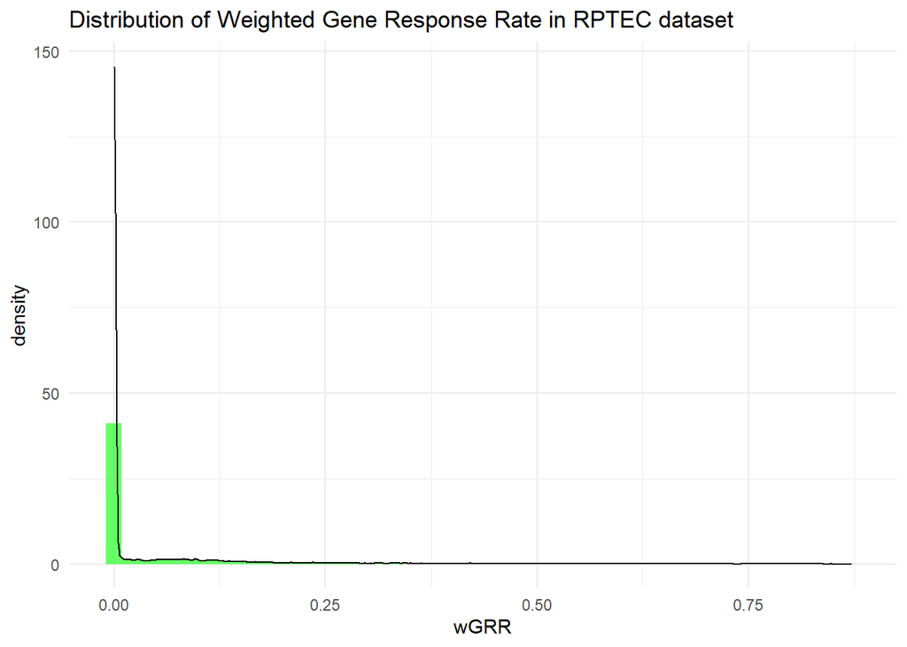

```r
ggplot(GRR_vs_eg_score, aes(x = wGRR)) +
  geom_histogram(aes(y = ..density..), bins = 50, fill = "green", alpha = 0.6) +
  geom_density(color = "black") +
  theme_minimal() + labs(title = "Distribution of Weighted Gene Response Rate in RPTEC dataset")
```

## Visualize GRR vs EG score with a linear fit

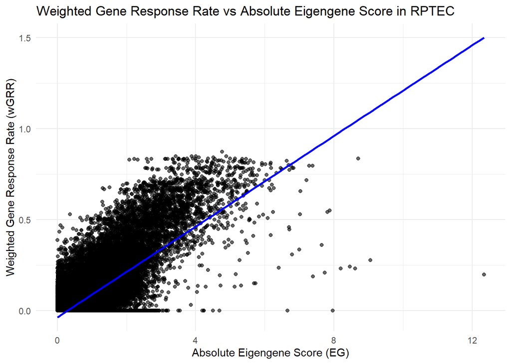

```r
ggplot(GRR_vs_eg_score, aes(x = abs_eg_score, y = wGRR)) +
  geom_point(alpha = 0.6) +
  geom_smooth(method = "lm", se = FALSE, color = "blue") +
  theme_minimal() +
  labs(
    title = "Weighted Gene Response Rate vs Absolute Eigengene Score in RPTEC",
    x = "Absolute Eigengene Score (EG)",
    y = "Weighted Gene Response Rate (wGRR)"
  )
```

The linear fit does not follow the trend of the wGRR vs EG, as expected due to the logarithmic distribution of the wGRR. Next we will try to fit a different, logarthmic fit. To detect significant outliers.

## Binomial Generalized Linear Model (GLM)

### Fitting

```r
glm_data <- GRR_vs_eg_score %>%
  filter(!is.na(wGRR), !is.na(abs_eg_score)) # This filtering was performed as the fit was first tested on a subset, but the filtering is irrelevant for the whole dataset as there are no NAs
```

```r
glm_fit <- glm(
  wGRR ~ abs_eg_score,
  data = glm_data,
  family = quasibinomial(link = "logit") # quasibinomial as the wGRR is a proportion multiplied by a continuous variable, the cor_eg.
)
```

```r
# Make predictions and residuals
glm_predictions <- predict(glm_fit, type = "response")
glm_dev_resid <- residuals(glm_fit, type = "deviance")

# Combine into a new dataframe
GRR_glm_fit_df <- GRR_vs_eg_score %>%
  mutate(
    fitted_prob = glm_predictions,
    fitted_sig_genes = fitted_prob * module_size,
    residual = sig_genes - fitted_sig_genes,
    dev_resid = glm_dev_resid
  )
```

### Evaluating the fit

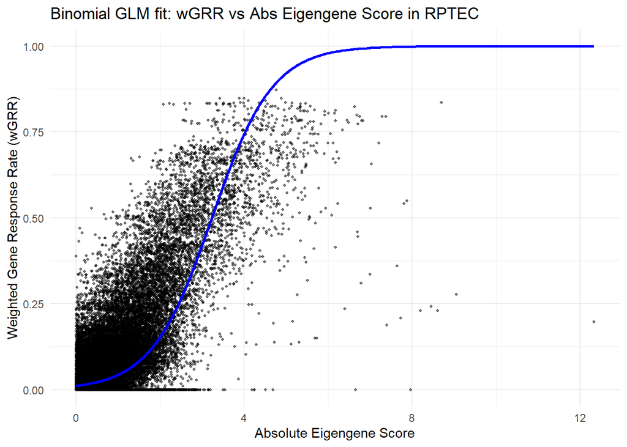

```r
ggplot(GRR_glm_fit_df, aes(x = abs_eg_score, y = wGRR)) +
  geom_point(alpha = 0.5, size = 0.8) +
  geom_line(aes(y = fitted_sig_genes / module_size), color = "blue", size = 1) +
  theme_minimal() +
  labs(
    title = "Binomial GLM fit: wGRR vs Abs Eigengene Score in RPTEC",
    x = "Absolute Eigengene Score",
    y = "Weighted Gene Response Rate (wGRR)"
  )
```

```r
summary(glm_fit)
```

```
##
## Call:
## glm(formula = wGRR ~ abs_eg_score, family = quasibinomial(link = "logit"),
##     data = glm_data)
##
## Coefficients:
##              Estimate Std. Error t value Pr(>|t|)
## (Intercept)  -4.48078    0.05577  -80.34   <2e-16 ***
## abs_eg_score  1.38603    0.03147   44.04   <2e-16 ***
## ---
## Signif. codes:  0 '***' 0.001 '**' 0.01 '*' 0.05 '.' 0.1 ' ' 1
##
## (Dispersion parameter for quasibinomial family taken to be 2.924727)
##
##     Null deviance: 13295.2  on 72155  degrees of freedom
## Residual deviance:  6407.1  on 72154  degrees of freedom
## AIC: NA
##
## Number of Fisher Scoring iterations: 6
```

```r
deviance(glm_fit) / df.residual(glm_fit)
```

```
## [1] 0.08879763
```

```r
1 - (glm_fit$deviance / glm_fit$null.deviance)
```

```
## [1] 0.5180877
```

### Significant outliers

For each module and sample, we compare the observed number of significant genes to the expected number based on the binomial GLM, and calculate a two-sided z-score and p-value using the binomial standard error. By doing this, the significant outlying modules from the glm fit are identified. Above and Below fit genes are identified for later analysis.

```r
GRR_glm_fit_df <- GRR_glm_fit_df %>%
  mutate(
    se_fit = sqrt(module_size * fitted_prob * (1 - fitted_prob)),
    z_score = (sig_genes - fitted_sig_genes) / se_fit,
    p_value = 2 * pnorm(-abs(z_score))  # two-sided test
  )
```

```r
GRR_glm_fit_df <- GRR_glm_fit_df %>%
  mutate(outlier = p_value < 0.05)
```

```r
GRR_glm_fit_df <- GRR_glm_fit_df %>%
  mutate(
    outlier_direction = case_when(
      outlier & z_score > 0 ~ "Above fit",
      outlier & z_score < 0 ~ "Below fit",
      TRUE ~ "Not significant"
    )
  )
```

```r
GRR_glm_fit_df <- GRR_glm_fit_df %>%
  mutate(module = paste0("hRPTECTERT1_", module_number)) %>%
  left_join(module_annotation, by = "module")
```

```r
sum(GRR_glm_fit_df$outlier, na.rm = TRUE)
```

```
## [1] 10352
```

a total of 10352 outliers from the fit are found.

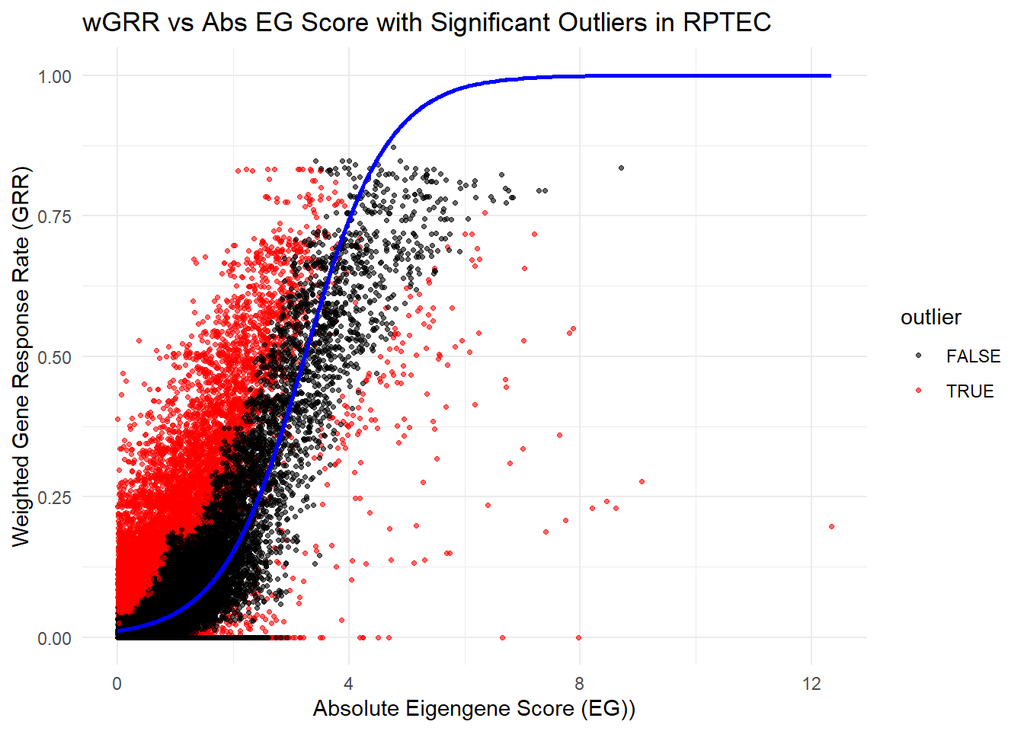

```r
ggplot(GRR_glm_fit_df, aes(x = abs_eg_score, y = wGRR)) +
  geom_point(aes(color = outlier), alpha = 0.6, size = 0.9) +
  geom_line(aes(y = fitted_sig_genes / module_size), color = "blue", size = 1) +
  scale_color_manual(values = c("black", "red")) +
  theme_minimal() +
  labs(
    title = "wGRR vs Abs EG Score with Significant Outliers in RPTEC",
    x = "Absolute Eigengene Score (EG))",
    y = "Weighted Gene Response Rate (GRR)"
  )
```

## Modules and conditions with most significant outliers’

Based on the binomial GLM fit, we will now find the modules and conditions with the most significant outliers

```r
significant_outliers_filtered <- GRR_glm_fit_df %>%
  filter(outlier)
```

```r
outliers_per_module <- significant_outliers_filtered %>%
  count(module_number, sort = TRUE)
```

```r
outliers_per_sample <- significant_outliers_filtered %>%
  count(sample_id, sort = TRUE)
```

```r
head(outliers_per_module, 10) # Top modules with outliers
```

```
## # A tibble: 10 × 2
##    module_number     n
##            <dbl> <int>
##  1             1   214
##  2             2   214
##  3             5   207
##  4             8   204
##  5             3   202
##  6             6   196
##  7             7   183
##  8             9   180
##  9             4   178
## 10            17   149
```

```r
head(outliers_per_sample, 10) # Top cconditions with outliers
```

```
## # A tibble: 10 × 2
##    sample_id                                        n
##    <chr>                                        <int>
##  1 LU_HRPTECTERT1_SINGLE_ZOLENDRONICACID_T3_C3    154
##  2 LU_HRPTECTERT1_SINGLE_OMEPRAZOL_T3_C3          151
##  3 LU_HRPTECTERT1_SINGLE_CISPLATIN_T3_C3          139
##  4 LU_HRPTECTERT1_SINGLE_ARISTOLOCHICACID_T3_C2   137
##  5 LU_HRPTECTERT1_SINGLE_CISPLATIN_T2_C3          125
##  6 LU_HRPTECTERT1_SINGLE_RAPAMYCIN_T3_C1          125
##  7 LU_HRPTECTERT1_SINGLE_DOXORUBICIN_T3_C3        123
##  8 LU_HRPTECTERT1_SINGLE_AMPHOTERICINB_T3_C1      122
##  9 LU_HRPTECTERT1_SINGLE_CYCLOSPORINA_T3_C2       122
## 10 LU_HRPTECTERT1_SINGLE_ARISTOLOCHICACID_T2_C2   121
```

### Outliers per module: total, below and above the fit with human annotation

Here, we will visualize the modules with the most outliers and its human annotation. Total, below and above the Binomial GLM fit.

#### Total outliers from the GLM fit

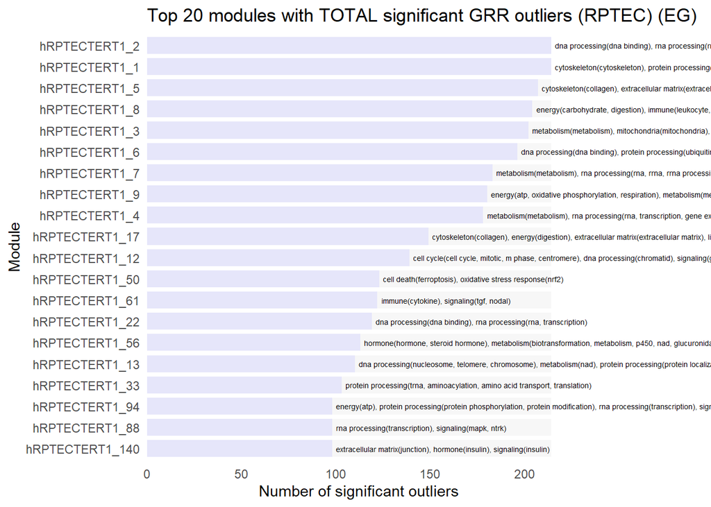

```r
threshold <- 300  # Same threshold

GRR_glm_fit_df %>%
  filter(outlier) %>%
  count(module, annotation, sort = TRUE) %>%
  slice_max(n, n = 20, with_ties = FALSE) %>%
  mutate(
    max_n = max(n),
    hjust_val = ifelse(n < threshold, 0, 1.1),
    label_pos = ifelse(n < threshold, n + 2, n - 2)
  ) %>%
  ggplot(aes(x = reorder(module, n))) +
  geom_col(aes(y = max_n), fill = "grey97", width = 0.8) +
  geom_col(aes(y = n), fill = "lavender", width = 0.8) +
  geom_text(
    aes(y = label_pos, label = annotation, hjust = hjust_val),
    size = 1.8, color = "black"
  ) +
  coord_flip(clip = "off") +
  scale_y_continuous(
    limits = c(0, max(GRR_glm_fit_df %>%
      filter(outlier) %>%
      count(module) %>%
      slice_max(n, n = 20, with_ties = FALSE) %>%
      pull(n)) + 10),
    expand = c(0, 0)
  ) +
  theme_minimal() +
  theme(
    plot.margin = margin(5.5, 100, 5.5, 5.5),
    panel.grid.major = element_blank(),
    panel.grid.minor = element_blank()
  ) +
  labs(
    title = "Top 20 modules with TOTAL significant GRR outliers (RPTEC) (EG)",
    x = "Module",
    y = "Number of significant outliers"
  )
```

#### Outliers above the GLM fit

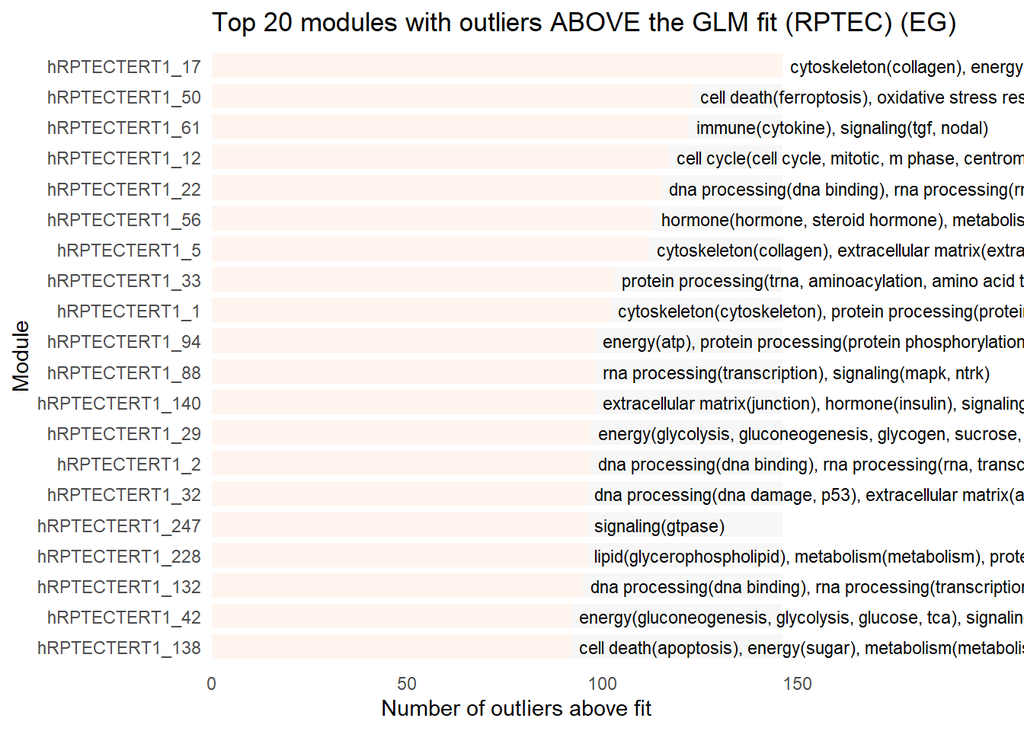

```r
threshold <- 300  # Threshold for switching annotation position

GRR_glm_fit_df %>%
  filter(outlier_direction == "Above fit") %>%
  count(module, annotation, sort = TRUE) %>%
  slice_max(n, n = 20, with_ties = FALSE) %>%
  mutate(
    max_n = max(n),
    hjust_val = ifelse(n < threshold, 0, 1.1),
    label_pos = ifelse(n < threshold, n + 2, n - 2)
  ) %>%
  ggplot(aes(x = reorder(module, n))) +
  geom_col(aes(y = max_n), fill = "grey97", width = 0.8) +
  geom_col(aes(y = n), fill = "seashell", width = 0.8) +
  geom_text(
    aes(y = label_pos, label = annotation, hjust = hjust_val),
    size = 3, color = "black"
  ) +
  coord_flip(clip = "off") +
  scale_y_continuous(
    limits = c(0, max(GRR_glm_fit_df %>%
      filter(outlier_direction == "Above fit") %>%
      count(module) %>%
      slice_max(n, n = 20, with_ties = FALSE) %>%
      pull(n)) + 10),
    expand = c(0, 0)
  ) +
  theme_minimal() +
  theme(
    plot.margin = margin(5.5, 100, 5.5, 5.5),
    panel.grid.major = element_blank(),
    panel.grid.minor = element_blank()
  ) +
  labs(
    title = "Top 20 modules with outliers ABOVE the GLM fit (RPTEC) (EG)",
    x = "Module",
    y = "Number of outliers above fit"
  )
```

#### Outliers below the GLM fit

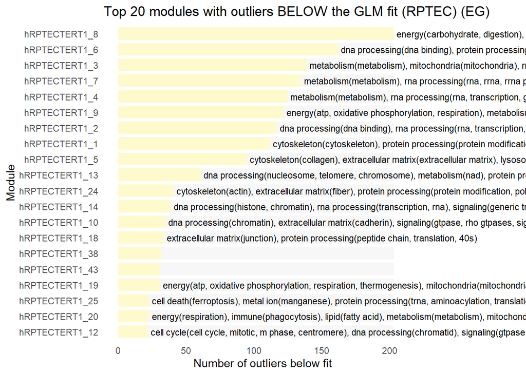

```r
threshold <- 400  # Threshold for annotation in plot

GRR_glm_fit_df %>%
  filter(outlier_direction == "Below fit") %>%
  count(module, annotation, sort = TRUE) %>%
  slice_max(n, n = 20, with_ties = FALSE) %>%
  mutate(
    max_n = max(n),
    hjust_val = ifelse(n < threshold, 0, 1.1),       # outside or inside
    label_pos = ifelse(n < threshold, n + 2, n - 2)  # offset label position
  ) %>%
  ggplot(aes(x = reorder(module, n))) +

  # Background bar
  geom_col(aes(y = max_n), fill = "grey97", width = 0.8) +

  # Foreground bar (actual value)
  geom_col(aes(y = n), fill = "lemonchiffon", width = 0.8) +

  # Smart annotation positioning
  geom_text(
    aes(y = label_pos, label = annotation, hjust = hjust_val),
    size = 3, color = "black"
  ) +

  coord_flip(clip = "off") +  # Flip axes for horizontal bars

  # Y-axis limits: no exessive white space
  scale_y_continuous(limits = c(0, max(GRR_glm_fit_df %>%
    filter(outlier_direction == "Below fit") %>%
    count(module) %>%
    slice_max(n, n = 20, with_ties = FALSE) %>%
    pull(n)) + 10)) +

  theme_minimal() +
  theme(
    plot.margin = margin(5.5, 100, 5.5, 5.5),
    panel.grid.major = element_blank(),
    panel.grid.minor = element_blank()
  ) +
  labs(
    title = "Top 20 modules with outliers BELOW the GLM fit (RPTEC) (EG)",
    x = "Module",
    y = "Number of outliers below fit"
  )
```

### Outliers per sample: above, below and total.

Now, we will assess what conditions have the most outliers. Total, below and above the binomial GLM fit.

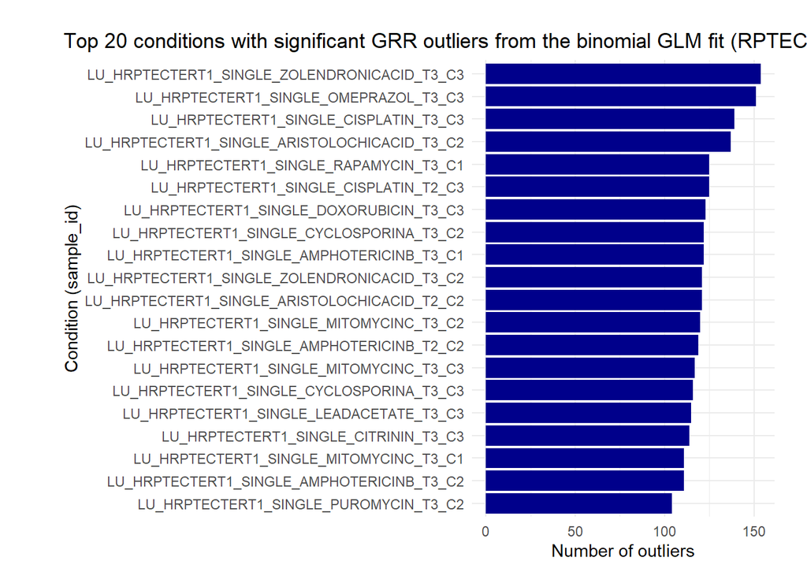

```r
outliers_per_sample %>%
  top_n(20, n) %>%
  ggplot(aes(x = reorder(sample_id, n), y = n)) +
  geom_col(fill = "darkblue") +
  coord_flip() +
  theme_minimal() +
  ggtitle("Top 20 conditions with significant GRR outliers from the binomial GLM fit (RPTEC) (EG)") +
  theme(
    plot.title.position = "plot",
    plot.title = element_text(hjust = 0),
    plot.margin = margin(20, 20, 10, 40) # top, right, bottom, left
  ) +
  labs(
    x = "Condition (sample_id)",
    y = "Number of outliers"
  )
```

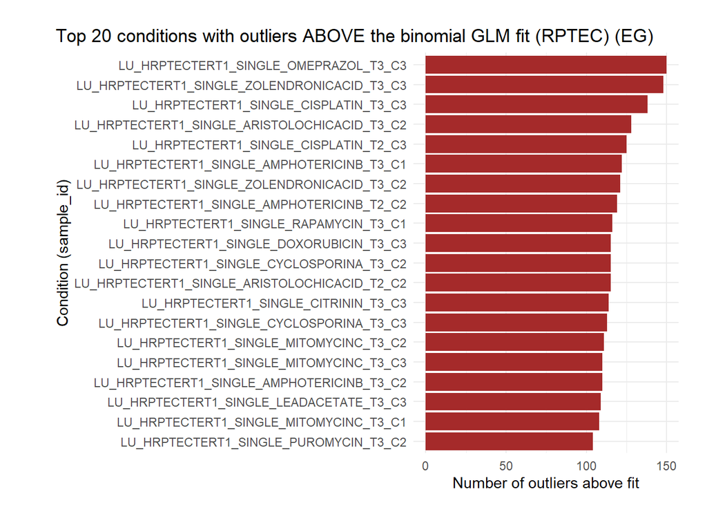

```r
GRR_glm_fit_df %>%
  filter(outlier_direction == "Above fit") %>%
  count(sample_id, sort = TRUE) %>%
  top_n(20, n) %>%
  ggplot(aes(x = reorder(sample_id, n), y = n)) +
  geom_col(fill = "brown") +
  coord_flip() +
  theme_minimal() +
  ggtitle("Top 20 conditions with outliers ABOVE the binomial GLM fit (RPTEC) (EG)") +
  theme(
    plot.title.position = "plot",
    plot.title = element_text(hjust = 0),
    plot.margin = margin(20, 20, 10, 40)
  ) +
  labs(
    x = "Condition (sample_id)",
    y = "Number of outliers above fit"
  )
```

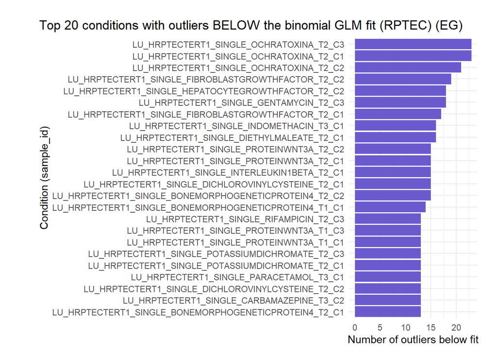

```r
GRR_glm_fit_df %>%
  filter(outlier_direction == "Below fit") %>%
  count(sample_id, sort = TRUE) %>%
  top_n(20, n) %>%
  ggplot(aes(x = reorder(sample_id, n), y = n)) +
  geom_col(fill = "slateblue") +
  coord_flip() +
  theme_minimal() +
  ggtitle("Top 20 conditions with outliers BELOW the binomial GLM fit (RPTEC) (EG)") +
  theme(
    plot.title.position = "plot",
    plot.title = element_text(hjust = 0),
    plot.margin = margin(20, 20, 10, 40)
  ) +
  labs(
    x = "Condition (sample_id)",
    y = "Number of outliers below fit"
  )
```

# Outliers per number of modules * number of samples: density of outliers for comparison with other datasets and techniques.

To compare this with PHH the number of outliers will be compared relative to the total modules and conditions. Also, to have a more arbitrary number to compare with the other topology-based scoring methods

```r
total_modules_all <- GRR_glm_fit_df %>%
  filter(module_number != 0) %>%
  summarise(n = n_distinct(module_number)) %>%
  pull(n) # for normalization
```

```r
total_conditions_all <- GRR_glm_fit_df %>%
  filter(module_number != 0) %>%
  summarise(n = n_distinct(sample_id)) %>%
  pull(n) # for normalization
```

```r
# Making a summarizing df for comparing with other datasets and scoring algorithms
outlier_density <- GRR_glm_fit_df %>%
  filter(outlier, module_number != 0) %>%
  group_by(outlier_direction) %>%
  summarise(
    total_outliers = n(),
    .groups = "drop"
  ) %>%
  bind_rows(
    tibble(
      outlier_direction = "Total",
      total_outliers = sum(.$total_outliers)
    )
  ) %>%
  mutate(
    total_modules = total_modules_all,
    total_conditions = total_conditions_all,
    density = total_outliers / (total_modules * total_conditions)
  )
```

```r
print(outlier_density)
```

```
## # A tibble: 3 × 5
##   outlier_direction total_outliers total_modules total_conditions density
##   <chr>                      <int>         <int>            <int>   <dbl>
## 1 Above fit                   8528           291              248  0.118
## 2 Below fit                   1824           291              248  0.0253
## 3 Total                      10352           291              248  0.143
```

Final outliers from the fit. Will be visualized in a stacked bar chart and compared with other topology based methods.